```python
# Load packages
import numpy as np
import pandas as pd
import matplotlib.pyplot as plt
import seaborn as sns
from sklearn import datasets, linear_model
from sklearn.model_selection import train_test_split, cross_val_score, cross_val_predict, cross_val_score, GridSearchCV, StratifiedKFold, StratifiedShuffleSplit
from sklearn import model_selection, metrics
from sklearn.linear_model import LogisticRegression
from sklearn.metrics import roc_auc_score, roc_curve
from sklearn.preprocessing import StandardScaler
from sklearn.linear_model import ElasticNet, SGDClassifier
from sklearn.preprocessing import StandardScaler
from sklearn.neighbors import KNeighborsClassifier
from sklearn.cross_validation import train_test_split
from sklearn.tree import DecisionTreeClassifier
from sklearn.metrics import accuracy_score
from sklearn import tree
from sklearn.tree import DecisionTreeClassifier
from sklearn.metrics import roc_auc_score
from sklearn.grid_search import GridSearchCV
from sklearn.ensemble import RandomForestClassifier
from sklearn.ensemble import AdaBoostClassifier
from sklearn.ensemble import GradientBoostingClassifier
from sklearn import cross_validation, metrics
from sklearn.grid_search import GridSearchCV
import matplotlib.lines as mlines
import matplotlib.transforms as mtransforms
from sklearn.calibration import calibration_curve
import pydotplus as pydot
from IPython.display import Image
from sklearn.externals.six import StringIO
from sklearn.ensemble import AdaBoostClassifier
from sklearn.metrics import confusion_matrix

%matplotlib inline
```

# 0. Az adatok betöltése

Legelőször az adatbázist beolvastam, annak érdekében, hogy az első intuíciót meg kapjam a benne található adatokról.

```python
data = pd.read_csv('otp_datascientist_beadando.csv', sep = ';')
```

Első ránézésre, hogyan néz ki a nyers adatbázisunk:

```python
data.head()
```

|  | age | job | marital | education | default | balance | housing | loan | contact | day | month | duration | campaign | pdays | previous | poutcome | y |
| --- | --- | --- | --- | --- | --- | --- | --- | --- | --- | --- | --- | --- | --- | --- | --- | --- | --- |
| 0 | 58 | management | married | tertiary | no | 2143 | yes | no | unknown | 5 | may | 261 | 1 | -1 | 0 | unknown | no |
| 1 | 44 | technician | single | secondary | no | 29 | yes | no | unknown | 5 | may | 151 | 1 | -1 | 0 | unknown | no |
| 2 | 33 | entrepreneur | married | secondary | no | 2 | yes | yes | unknown | 5 | may | 76 | 1 | -1 | 0 | unknown | no |
| 3 | 47 | blue-collar | married | unknown | no | 1506 | yes | no | unknown | 5 | may | 92 | 1 | -1 | 0 | unknown | no |
| 4 | 33 | unknown | single | unknown | no | 1 | no | no | unknown | 5 | may | 198 | 1 | -1 | 0 | unknown | no |

```python
data.shape
```

```
(45211, 17)
```

A nyers adatbázisnak 45211 sora (megfigyelése) és 17 oszlopa (változója) van.

# 1. A probléma megfogalmazása: elemzési célok meghatározása (Business Understanding)

Az adatbázis egy portugál bank marketing kampányából származó adatokat tartalmaz. A marketing kampány során valószínűleg telefonos sales tevékenységet folytattak, aminek célja a bank által forgalmazott egyik kötvénynek az eladása volt. Az adatbázis egyes sorában egyének találhatóak az oszlopok pedig az adott egyén tulajdonságaira vonatkoznak (pl. kor, iskolai végzettség, előző marketing kampányban való részvétel stb.), emellett tartalmazza az adatbázis azt az adatot is, hogy megvásárolta az egyén az ajánlott kötvényt vagy nem.

Az elemzésem célja, egy olyan modell megalkotása, ami az egyéni tulajdonságok alapján előrejelzi, hogy ki az aki meg fogja venni a terméket és ki az aki nem.  
A modell alkotás után célom még, hogy néhány jól magyarázó változó és a magyarázott válozó közötti kapcsolatot ismertessem.  
Majd, ajánlásokat teszek döntéshozóknak, az ismertetett eremények alapján.

Összefoglalva: A feladat egy bináris predikciós probléma egyéni tulajdonságok alapján arra nézve, hogy megvesznek egy terméket vagy sem.

# 2. Adatelemzés: adatfeltárás, adatminőség felmérése, adatelőkészítés:

## 2.1 Adatok megismerése (Data Understanding):

Először azt néztem meg, hogy melyik változók tartalmaznak hiányzó adatokat. Az adatbázisok sokszor hiányosak, és ilyenkor az elemző feladata, hogy:

- a) ha elhanyagolható mennyiségű hiányos adat található egyszerűen azokat a megfigyeléseket elhagyja
- b) ha nagy mennyiségben hiányoznak adatok valamilyen módon kontroláljon rá (pl. az adott változó átlagával/mediánjával/móduszával/regressziós módszerrel/stb.) töltse fel a hiányzó megfigyeléseket

```python
data.isnull().sum() #hány hiányzó változó van változónként
```

```
age          0
job          0
marital      1
education    0
default      0
balance      0
housing      1
loan         0
contact      1
day          0
month        2
duration     0
campaign     0
pdays        0
previous     0
poutcome     1
y            3
dtype: int64
```

#### Az adatbázisban nagyon kevés hiányzó változó található, emiatt én egyszerűen elhagytam azokat a megfigyeléseket, ahol valamelyik változó hiányos volt.

```python
data.dropna(inplace=True) #hinyzó (NA) adatok kidobása
```

```python
print(data.shape)
```

```
(45202, 17)
```

Ezzel a művelettel 9 megfigyelést vesztettünk el és így 45202 megfigyelésen fogjuk a további műveleteket elvégezni.

### A változók tulajdonságai:

Az egyes változókat közelebbről az alábbi okokból tartom fontosnak megvizsgálni:

- a) jobban megértjük vele azt, hogy milyen problémával állunk szemben (jelen esetben pl: az Y változónk balanced vagy inbalanced, stb.)
- b) kiszűrhetünk belőlük olyan értékeket, amik a valóságban nem fordulhatnak elő (jelen esetben pl: a hónap napjaira vonatkozó változóban a valóságban 1 és 31 között vannak az értékek, stb.)
- c) új változókat kreálhatunk belőlük (jelen esetben: csoportosítanunk szükséges e valamilyen változót vagy esetleg valamelyik folytonos változót kategórikus változóként szerepeltessünk és vica-verza)
- d) modellezési szempontból mérlegelhetjük, hogy milyen adatokat használjunk fel a az adott probléma vizsgálatakor (jelen esetben: tartalmaz e vajon olyan adatot, amit nem tanácsos felhasználni vagy sem?)

#### folytonos változók:

```python
data.describe()
```

|  | age | balance | day | duration | campaign | pdays | previous |
| --- | --- | --- | --- | --- | --- | --- | --- |
| count | 45202.000000 | 45202.000000 | 45202.000000 | 45202.000000 | 45202.000000 | 45202.000000 | 45202.00000 |
| mean | 40.936175 | 1362.284434 | 15.810053 | 258.115858 | 2.764081 | 40.196717 | 0.58035 |
| std | 10.619276 | 3045.027882 | 8.324412 | 257.420503 | 3.098267 | 100.128222 | 2.30363 |
| min | 18.000000 | -8019.000000 | 1.000000 | 0.000000 | 1.000000 | -1.000000 | 0.00000 |
| 25% | 33.000000 | 72.000000 | 8.000000 | 103.000000 | 1.000000 | -1.000000 | 0.00000 |
| 50% | 39.000000 | 448.000000 | 16.000000 | 180.000000 | 2.000000 | -1.000000 | 0.00000 |
| 75% | 48.000000 | 1427.750000 | 21.000000 | 319.000000 | 3.000000 | -1.000000 | 0.00000 |
| max | 95.000000 | 102127.000000 | 40.000000 | 4918.000000 | 63.000000 | 871.000000 | 275.00000 |

A fenti táblázatban az egyes változók leíró statisztikája látható. Kiolvasható belőle az egyes változók darabszáma, átlaga, szórása, minimuma, maximuma, kaphatunk egy első képet az eloszlásukról is)

Néhány példa, hogy ebből a táblázatból mit láthatunk:

- 'age' (=kor): látható, hogy az átlag életkor a telefonos kampány résztvevőire nézve ~41 év, a legfiatalabb résztvevő 18 éves a legidősebb pedig 95 éves. 75% a résztvevőknek 48 év alatti
- 'balance' (=számla egyenleg): mínusz értékek is találhatóak a számla egyenlegre vonatkozóan. Ez valószínűleg nem utal hibára. Lehet, hogy vannak olyan egyének akiknek tartozása van.
- 'day': van 40 es érték is a hónap napjaira vonatkozóan. Ez a gyakorlatban nem lehetséges. Később kezelni szükséges.
- 'previous' (=hányszor hívták fel az adott személyt előző telefonos kampányokban): változó esetében a letöbb esetben 0 szerepel, ami azt jelenti hogy a legtöbb ember, nem volt előzőleg felkeresve.
- A további folytonos változók rendben vannak és jól fel vannak töltve (nem hiányosak, ahogy az előbb is láttuk már)

#### kategorikus változók:

```python
data.describe(include=["object"])
```

|  | job | marital | education | default | housing | loan | contact | month | poutcome | y |
| --- | --- | --- | --- | --- | --- | --- | --- | --- | --- | --- |
| count | 45202 | 45202 | 45202 | 45202 | 45202 | 45202 | 45202 | 45202 | 45202 | 45202 |
| unique | 12 | 3 | 4 | 2 | 2 | 2 | 3 | 12 | 4 | 2 |
| top | blue-collar | married | secondary | no | yes | no | cellular | may | unknown | no |
| freq | 9728 | 27208 | 23194 | 44387 | 25121 | 37958 | 29278 | 13764 | 36952 | 39914 |

A fenti táblázatban a kategorikus változók néhány jellemzője látható. (pl: hány kategória található az adott változóra nézve, melyik a leggyakoribb elem és abból hány darab van abból.)

Néhány példa, hogy ebből a táblázatból mit láthatunk:

```python
data['y'].value_counts() #39914db no és 5288db yes
```

```
no     39914
yes     5288
Name: y, dtype: int64
```

- A 'job' (=foglalkozás) kategóriában letöbbször előforduló elem a 'blue-colar', amiből 9728 darab található. De ezen kívül további 11 foglalkozásra van bontva

### A fent ismertetett változókat ábrákon is megjeleníthetjük

```python
categorical_vars = data.describe(include=["object"]).columns
continuous_vars = data.describe().columns
```

#### A folytonos változók hisztogramja:

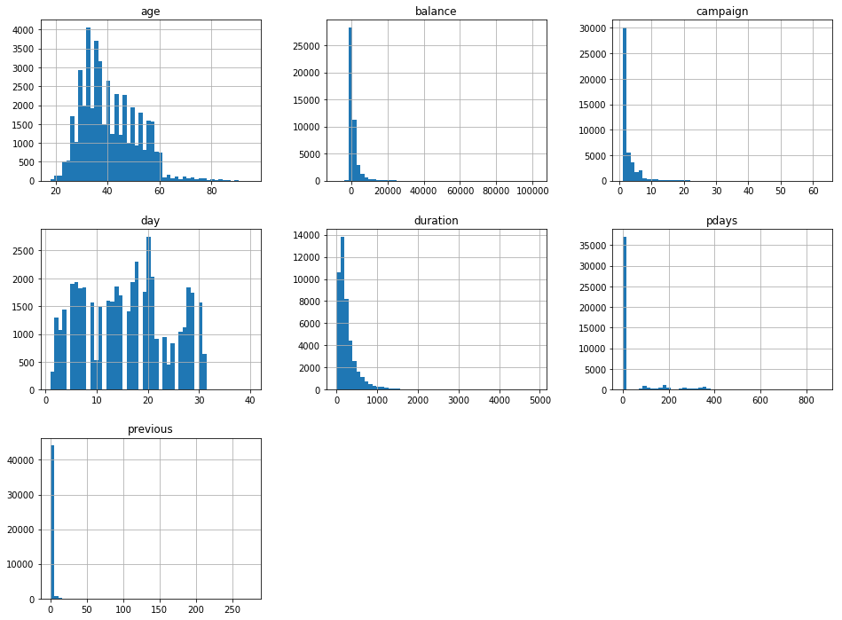

```python
plot = data.hist(column=continuous_vars, figsize = (16, 12), bins = 50)
plt.savefig('continous2.png')
```

#### A kategórikus változók hisztogramja:

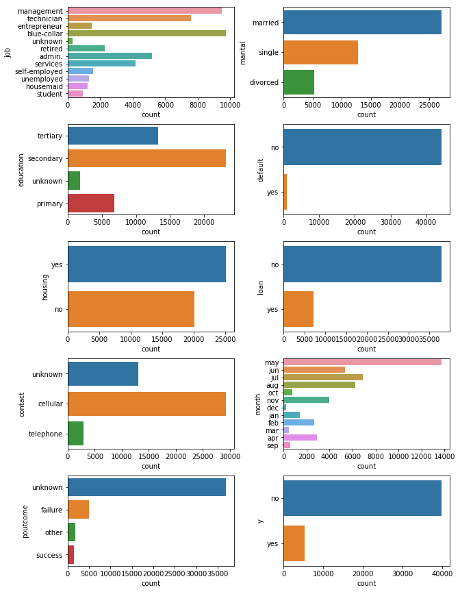

```python
fig, axes = plt.subplots(5, 2, figsize=(10, 15))
plt.subplots_adjust(left=None, bottom=None, right=None, top=None, wspace=0.3, hspace=0.3)

for i, ax in enumerate(axes.ravel()):
    plot = sns.countplot(y = categorical_vars[i], data=data, ax=ax)
```

## 2.2 Az adatok előkészítése (Data Preparation):

A fenti ábrák alapján az elemző feladata, hogy esetleg módosítson a változókon. A következő sorokban az általam szükségesnek ítélt módosítások láthatók.  
Emellett az elemző ilyenkor már gondolkodhat azon, hogy milyen problémával áll szemben, milyen modellt válasszon, ahhoz milyen adatok szükségesek, hogyan kell azokat megadni a modellben. (pl:át szükséges e az eloszlásokat transzformálni, stb.). Gondolok itt arra, hogy egy lineáris modell esetében az adatokat ahol erre lehetősége van normális eloszlásúvá szükséges transzformálni (pl. a logaritmusát venni)

### A Fenti táblázatok és ábrák alapján az alábbi módosításokat végeztem el:

#### 'day' változó:

Miért? 31-nél nagyobb napok is szerepelnek benne, valamint ezt inkább kategórikus változóként szeretném szerepeltetni és csoportot képezni belőle, mert évre vonatkozó adat nem található az adatbázisban. Ha lenne ilyen adat, akkor tudnék belőle hétköznap és hétvége csoportot képezni belőlük.

```python
data.groupby('day').size().tail() #van 3db 40 napos hónapra vonatkozó megfigyelés
```

```
day
28    1830
29    1745
30    1566
31     643
40       3
dtype: int64
```

```python
data.loc[data.day == 40, 'day'] = 31 # --> átrakom a 31 naposokhoz, kevés ezért úgy gondolom megtehetem
```

```python
data['day'] = pd.cut(data['day'], [1, 10, 20, 31])
#3 kategóriára osztom napok szerint a hónapokat: eleje, közepe, vége.
#Nincs nagyon értelme a hónap napjait naponként szerepeltetni, mivel nem tudjuk hogy az adataink melyik és hogy csak
#egy évre vonatkoznak-e. Emiatt nem tudjuk megbontani őket pl. hétköznap/hétvégére
```

```python
data.groupby('day').size()
```

```
day
(1, 10]     13394
(10, 20]    18386
(20, 31]    13100
dtype: int64
```

```python
data['day'] = data['day'].astype(object) #kategórikus változóvá konvertálom a napokat
```

#### 'previous' változó:

Ezt a változót is inkább kategorikusként szeretném szerepeltetni, és csoportosítom is, hogy ne legyen túl sok kategória bennük.

```python
data['previous'].value_counts().head()
```

```
0    36947
1     2771
2     2106
3     1141
4      714
Name: previous, dtype: int64
```

```python
data.loc[data.previous > 5, 'previous'] = '5+'
#az az egyént akit előzőleg 5x vagy többször keresték meg az 5+ nevű kategóriába sorolom
```

```python
data['previous'].value_counts()
#több értelmét látom ezt így szerepeltetni, mivel nagyon sok olyan egyén van aki 0x lett megkeresve
```

```
0     36947
1      2771
2      2106
3      1141
5+     1064
4       714
5       459
Name: previous, dtype: int64
```

#### 'duration változó':

Érdemes ennek a változónak a logaritmusát venni, hogy közelebb álljon a normál eloszláshoz. A modellezési részben jól fog jönni a lineáris modell alkalmazásakor.

```python
data['duration'] = data['duration'] + 1
#hozzáadok egyet a duration-höz, mert 0-nak nem értelmezhető a logaritmusa, és a változóra nincs nagy hatással
#mert ez az adat valószínűleg másodpercben van megadva, így 1 mp elhanyagolható
```

```python
data['duration'] = np.log(data['duration']) #veszem a logaritmusát
```

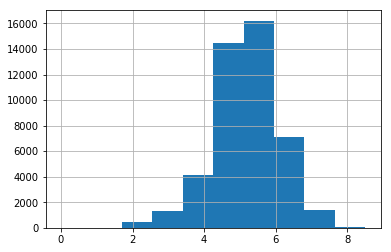

```python
duration_hist = data['duration'].hist() #megnézem az eloszlását
```

Majdnem teljesen normál eloszlású --> jobb

#### 'age' valatozó:

Az életkor változó logaritmusát is veszem, mert bízom benne, hogy jobban fog hasonlítani a normál eloszláshoz.

```python
data['age'] = np.log(data['age'])
```

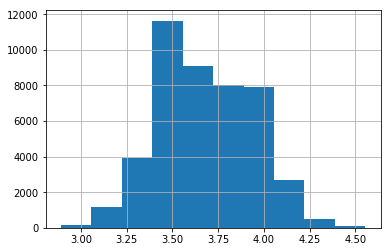

```python
age_hist = (data['age']).hist() #jobb, ezért így hagyom
```

A többi változót jónak ítélem meg, így további módsításokat nem végzek rajtuk. Esetleg a modell alkotás végén, ha semmilyen értelmezheső, vagy túl jó eredmény jön ki, akkor elgondolkozom, hogy mit lehet kezdeni az egyes változókkal.

pl: a 'balance' változót szükséges-e normalizálni. (Kicsit gondolkozni szükséges rajta, mivel negatív és 0 értékeket is tartalmaz így a logaritmusát trükkösen lehet csak venni)

#### Mielőtt a következő részre térnék, a kategorikus valótokat és a folytonos változókat elmentem egy változóba:

```python
categorical_vars = data.describe(include=["object"]).columns
continuous_vars = data.describe().columns
```

Melyek ezek?

```python
categorical_vars
```

```
Index(['job', 'marital', 'education', 'default', 'housing', 'loan', 'contact',
       'day', 'month', 'previous', 'poutcome', 'y'],
      dtype='object')
```

```python
continuous_vars
```

```
Index(['age', 'balance', 'duration', 'campaign', 'pdays'], dtype='object')
```

# 2.3 Melyik magyarázó változó magyarázza első ránézésre a magyarázott változót?

Mielött a ML-es modelleket megalkotnánk. Érdemes náhány magyarázó és a magyarázott változó közötti összefüggést megvizsgálnunk, hogy megnézzük egymagukban milyen magyarázó erővel bírnak. Ez szükséges is annak érdekében, hogy egy átfogó képet kapjunk az adatokról.

```python
mean_data = data.groupby('y').mean()
mean_data['age'] = np.exp(mean_data['age'])
mean_data['duration'] =  np.exp(mean_data['duration'])
```

```python
mean_data
```

| y | age | balance | duration | campaign | pdays |
| --- | --- | --- | --- | --- | --- |
| no | 39.617707 | 1303.728767 | 157.068414 | 2.846595 | 36.426442 |
| yes | 39.669583 | 1804.264561 | 419.788797 | 2.141263 | 68.654879 |

```python
median_data = data.groupby('y').median()
median_data['age'] = np.exp(median_data['age'])
median_data['duration'] =  np.exp(median_data['duration'])
median_data
```

| y | age | balance | duration | campaign | pdays |
| --- | --- | --- | --- | --- | --- |
| no | 39.0 | 417 | 165.0 | 2 | -1 |
| yes | 38.0 | 733 | 427.0 | 2 | -1 |

- a fenti táblázatból azt a következtetést vonhatjuk le hogy valószínűleg a
  - balance
  - duration
  - pdays
  - és talán a campaign változó jól magyarázhatja az Y-t vagyis a termék megvásárlására hatással vannak.

#### Mi a helyzet a kategórikus változók Y-ra történő hatásukkal?

job:

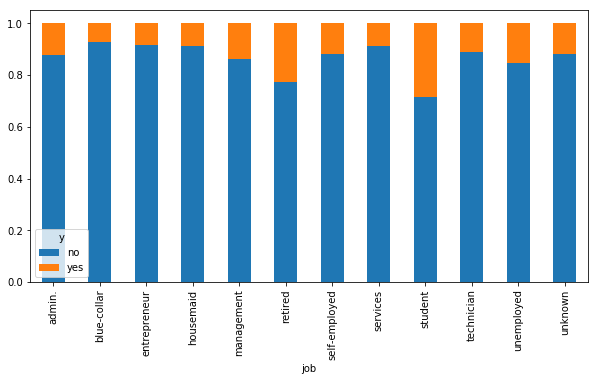

```python
table=pd.crosstab(data.job,data.y)
plot = table.div(table.sum(1).astype(float), axis=0).plot(kind='bar', stacked=True, figsize = (10, 5))
```

- sok a diák és a nyugdíjas foglalkozású ember vesz a termékből a többi kategóriához képest. Ez a változót is lehet hogy érdemes szerepeltetni a modellünkben

day:

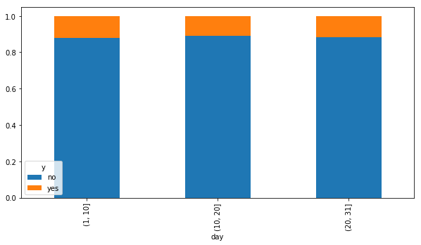

```python
table=pd.crosstab(data.day,data.y)
plot = table.div(table.sum(1).astype(float), axis=0).plot(kind='bar', stacked=True, figsize = (10,5))
```

- önmagában nem jól magyaráz

putcome:

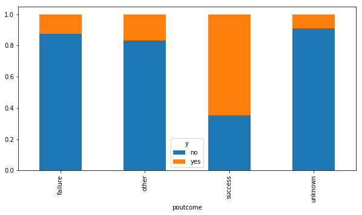

```python
table=pd.crosstab(data.poutcome,data.y)
plot = table.div(table.sum(1).astype(float), axis=0).plot(kind='bar', stacked=True, figsize = (10,5))
```

- Akiknek előzőleg sikeresen adtak el egy terméket az nagy arányban vesz ebben a kampányban is. Ez a változó valószínüleg jól magyaráz

Education:

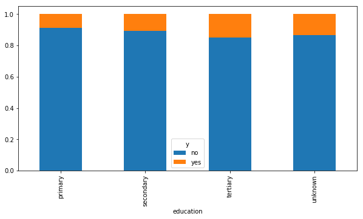

```python
table=pd.crosstab(data.education,data.y)
plot = table.div(table.sum(1).astype(float), axis=0).plot(kind='bar', stacked=True, figsize = (10,5))
```

- Valószínűleg kevés magyarázó erővel bír így önmagában

month:

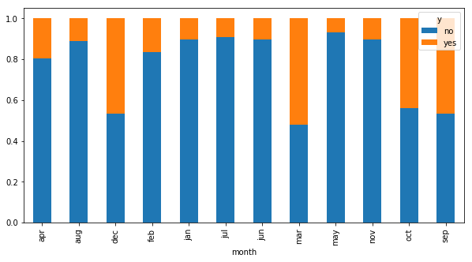

```python
table=pd.crosstab(data.month,data.y)
plot = table.div(table.sum(1).astype(float), axis=0).plot(kind='bar', stacked=True, figsize = (10,5))
```

Egyes hónapokban nagyon nagy arányban vásárolnak, bírhat magyarázó erővel

# 3. A probléma modellezése (Modelling):

A probléma elemzését az 'sklearn' nevű python csomaggal végeztem.

- először külön választottam az adatokat Train és Test set-re (80-20), ezután
- Több modellcsoporton, több paraméterrel GridSearch-el kiválasztottam az adott csoportra vonatkozó legjobb modell paramétereket CrossValidation(CV = 5) alkalmazásával. Ezzel a módszerrel kontrolálhatunk over és under fittingre.
- A legjobb modell paraméter kiválasztása során a az adott modell ROC/AUC mutatószámát vettem figyelembe. Ez egy jobb mutatószám a kétváltozós magyarázott változóval rendelkező modellek esetében, mint az pontosság (=Accuracy). Főleg unbalanced Y változó esetében.
- A modellcsoportból ROC/AUC alapján kiválasztott modelleket a végén különböző módszerekkel összehasonítottam, majd
- különböző mérőszámok/ és ábrák alapján egy végső modellt választottam

Az 'sklearn' python csomagnak szükséges manuálisan végrehajtani a one-hot encodingot (vagyis manuálisan szükséges a kategórikus változókból dummy változókat kreálnunk). Ez is tartalmazza a következő rész.

## 3.1 Kis kitérő: egy megfontolandó kérdés, az ML modellek futtatása előtt:

- A 'duration' változó, ami azt mutatja hogy milyen hosszúsúgú a telefonbeszélgetés, ami után az egyén a bankfiókban vagy egyéb más helyen megvásárolhatja a terméket egy kérdést vet fel: olyan információt hordoz, amit az adott egyénről a telefonos megkeresés előtt nem tudható.
- Emiatt, még mielőtt belekezdnénk a ML modellek megalkotásába egy fontos kérdést kell megválaszolnunk:
  - Felhasználhatunk-e a predikciónkhoz olyan adatokat, amit a telefonos megkeresés előtt nem áll rendelkezésünkre?
    - Ha igen, akkor ezt a változót megtartjuk a modelljeink során
    - Ha nem akkor kidobjuk és nem használjuk fel a modellezés során

#### Én a modellezés során nem használom fel ezt a változót, mert úgy gondolom, hogy üzleti szempontból nem lesz hasznos a modellem, ellenben nagyon jól fog prédikálni

Már ezt az egy változót szerepeltetve is magas AUC/ROC értéket kapunk, ami jó prédikációkat utal  
Lásd az alábbi egyváltozós logit modellt alább:

#### Egyváltozós logit modell a 'duration' változóval:

```python
# Szűrjük le a kívánt oszlopokat, amit a modellben szerepletetni szeretnénk:
X = ['duration', 'y']

categorical_vars = ['y'] #defináljuk a categórikus változókat

logit_data = data[X]
logit_data.head() #megjegyzés: 'duration' logaritmizálva van
```

|  | duration | y |
| --- | --- | --- |
| 0 | 5.568345 | no |
| 1 | 5.023881 | no |
| 2 | 4.343805 | no |
| 3 | 4.532599 | no |
| 4 | 5.293305 | no |

```python
logit_dummies_df = pd.get_dummies(logit_data, columns = categorical_vars, drop_first=True)
#dummy-k kreálása a kategórikus változókból
logit_dummies_df.columns
```

```
Index(['duration', 'y_yes'], dtype='object')
```

Az adatbázist ezután train és test adatbázisokra választom. Ez egy bevett gyarkolat a modellezés során. Arra szolgál, hogy elszeparált adatbázisokon tudjuk a modellt megalkotni, majd visszamérni.

```python
X_train, X_test, y_train, y_test = train_test_split(logit_dummies_df.drop('y_yes', axis=1),
                                                    logit_dummies_df['y_yes'],
                                                    test_size=0.2)
```

```python
#logit futtatása CV=5-tel, roc_auc-t figyelembe véve
simple_logit_final_cv = model_selection.cross_val_score(LogisticRegression(),
                                                  X_train, y_train,
                                                  cv=5,
                                                  scoring='roc_auc')
```

```python
print(simple_logit_final_cv)
print('Átlagos AUC CV=5-t használva: ',simple_logit_final_cv.mean().round(3))
```

```
[0.79970172 0.81285679 0.80825672 0.80659915 0.80912427]
Átlagos AUC CV=5-t használva:  0.807
```

Látható, hogy már ezzel az egy változóval is viszonylag magas AUC/ROC-t kapunk.

### Emiatt, valmint üzleti megfontolásból is, ezt a változót a következő részek modelleiből kidobtam Azonban, ha pusztán a predikció maximalizálása a cél, akkor ezt a változót tartsuk bent és nagyon jó predikciókat tehetünk. Erre tettem kisérletet a legeslegutolsó 'fun part' című részben.

## 3.2 Benchmark modell: Egyszerű logit néhány manuálisan megadott változóval

- A később következő bonyolultabb modelleket egy benchmark modellhez fogom mérni
- Miért? Mert meg szeretném nézni, hogy ezt a benchmark modellt mennyivel verik meg

Változók kiválasztása, amit az egyszerű logit modellben szerepeltetni szeretnénk:

```python
X = ['age','job', 'education','marital','balance', 'poutcome', 'y'] #a kiválaszott változók

categorical_vars = ['job', 'education', 'marital', 'poutcome', 'y'] #ezek közül a kategórikus változók

logit_data = data[X]
logit_data.head() #megjegyzés: az életkor logaritmizálva van
```

|  | age | job | education | marital | balance | poutcome | y |
| --- | --- | --- | --- | --- | --- | --- | --- |
| 0 | 4.060443 | management | tertiary | married | 2143 | unknown | no |
| 1 | 3.784190 | technician | secondary | single | 29 | unknown | no |
| 2 | 3.496508 | entrepreneur | secondary | married | 2 | unknown | no |
| 3 | 3.850148 | blue-collar | unknown | married | 1506 | unknown | no |
| 4 | 3.496508 | unknown | unknown | single | 1 | unknown | no |

```python
logit_dummies_df = pd.get_dummies(logit_data, columns = categorical_vars, drop_first=True)
logit_dummies_df.columns
```

```
Index(['age', 'balance', 'job_blue-collar', 'job_entrepreneur',
       'job_housemaid', 'job_management', 'job_retired', 'job_self-employed',
       'job_services', 'job_student', 'job_technician', 'job_unemployed',
       'job_unknown', 'education_secondary', 'education_tertiary',
       'education_unknown', 'marital_married', 'marital_single',
       'poutcome_other', 'poutcome_success', 'poutcome_unknown', 'y_yes'],
      dtype='object')
```

```python
# Csinálok egy dictonary-t, amibe a modellek eredményét menteni fogom a későbbi értékeléshez.
results = dict()
```

Train and test adatbázis szétválasztás:

```python
X_train, X_test, y_train, y_test = train_test_split(logit_dummies_df.drop('y_yes', axis=1),
                                                    logit_dummies_df['y_yes'],
                                                    test_size=0.2, # set it to higher number later
                                                   )
```

```python
#modell paramétereinek megadása: logit, train adatbázis, train magyarázott változó, cv,

simple_logit_final_cv = model_selection.cross_val_score(LogisticRegression(),
                                                  X_train, y_train,
                                                  cv=5,
                                                  scoring='roc_auc')
```

```python
print(simple_logit_final_cv)
print('---')
print('Átlagos ROC a benchmark logit modellt használva a train adatokon (CV = 5-tel): ', simple_logit_final_cv.mean().round(3))
results["Benchmark Logit"] = simple_logit_final_cv
```

```
[0.67164523 0.68191123 0.70501798 0.70626553 0.66487457]
---
Átlagos ROC a benchmark logit modellt használva a train adatokon (CV = 5-tel):  0.686
```

```python
simple_logit_final = LogisticRegression()
```

```python
#Későbbre:
simple_logit_final.fit(X_train, y_train)
simple_logit_final_pred_train = simple_logit_final.predict(X_train)
simple_logit_final_pred_test = simple_logit_final.predict(X_test)
```

```python
#Későbbre:
benchmark_logit_roc_auc = roc_auc_score(y_test, simple_logit_final.predict_proba(X_test)[:,1])
fpr_b, tpr_b, thresholds_b = roc_curve(y_test, simple_logit_final.predict_proba(X_test)[:,1])
```

# 3.3 ML modellek:

- a következő részben Machine Learning-es modelleket fogok alkamazni, aminken az az egyik tulajdonságuk, hogy autómaikusan választaniak változókat a modellbe és/vagy az összes változót szerepeltetik. Vagyis nem manuálisan kell hozzájuk változókat választani, hanem ez autómatikusan történik.

Az alábbi modelleket futtatam:

- ElasticNet modell
- KNN modell
- Egyszerű döntési fa modell
- Random Forest modell
- Gradient Boosting modell
- ADA Boost modell

## 3.3.1 Adat manipulálás az ML modellekhez

```python
# összes változó haználata
X = ['age','job','marital', 'education', 'default', 'balance', 'housing', 'loan',
     'contact', 'campaign', 'pdays', 'previous', 'poutcome', 'month', 'day', 'y']

categorical_vars = ['job', 'marital', 'education', 'default',
                   'housing', 'loan', 'contact', 'month', 'day',
                   'previous', 'poutcome', 'y']

ml_data = data[X]
```

```python
ml_data = pd.get_dummies(ml_data, columns = categorical_vars, drop_first=True) #one hot encoding for sklearn
ml_data.columns #nézzük meg most milyen oszlopaink vannak
# azt látjuk, hogy a kategórikus változókból dummy váltózókat kreáltunk
```

```
Index(['age', 'balance', 'campaign', 'pdays', 'job_blue-collar',
       'job_entrepreneur', 'job_housemaid', 'job_management', 'job_retired',
       'job_self-employed', 'job_services', 'job_student', 'job_technician',
       'job_unemployed', 'job_unknown', 'marital_married', 'marital_single',
       'education_secondary', 'education_tertiary', 'education_unknown',
       'default_yes', 'housing_yes', 'loan_yes', 'contact_telephone',
       'contact_unknown', 'month_aug', 'month_dec', 'month_feb', 'month_jan',
       'month_jul', 'month_jun', 'month_mar', 'month_may', 'month_nov',
       'month_oct', 'month_sep', 'day_(10, 20]', 'day_(20, 31]', 'previous_1',
       'previous_2', 'previous_3', 'previous_4', 'previous_5', 'previous_5+',
       'poutcome_other', 'poutcome_success', 'poutcome_unknown', 'y_yes'],
      dtype='object')
```

Train and test szétválasztás:

```python
X_train, X_test, y_train, y_test = train_test_split(ml_data.drop('y_yes', axis=1),
                                                    ml_data['y_yes'],
                                                    test_size=0.2,
                                                    random_state = 123)
```

## 3.3.2 ElasticNet model

Normalizálom az adatokat, a modell futtatása előtt:

```python
scaler = StandardScaler()
scaler.fit(X_train)

X_train_elastic = scaler.transform(X_train)
X_test_elastic = scaler.transform(X_test)
```

```python
param_grid = {'C': np.linspace(0.1, 1, 10),
              'penalty': ['l1', 'l2'],
             'class_weight': [None, 'balanced']
             }

# az igazat megvallva ez nem teljesen ElasticNet, csak nem találtam, hogy hoyg lehetne futtatni ELasticNet-et pythonban ezért
# ezt a penelized modellt alkalamztam

elastic_cv = GridSearchCV(LogisticRegression(),
                          param_grid = param_grid,
                          cv = 5,
                          scoring ='roc_auc')
```

```python
elastic_cv.fit(X_train_elastic, y_train)
print(elastic_cv.best_params_)
```

```
{'C': 0.1, 'class_weight': 'balanced', 'penalty': 'l1'}
```

A fenti paraméterek a legjobbak CV alapján

```python
elastic_final = elastic_cv.best_estimator_ #a legjobb modell kiválasztása
```

```python
elastic_final_cv = model_selection.cross_val_score(elastic_final,
                                              X_train_elastic, y_train,
                                              cv= 5,
                                              scoring='roc_auc')

print(elastic_final_cv)
print('---')
results["ElasticNet"] = elastic_final_cv #késöbbre a modell értékeléséhez
print("Átlagos ROC ElasticNet modellt használva a train adatokon (CV = 5-tel): ", elastic_final_cv.mean().round(3))
```

```
[0.76575523 0.75392356 0.7709176  0.77623288 0.76965732]
---
Átlagos ROC ElasticNet modellt használva a train adatokon (CV = 5-tel):  0.767
```

A kimenetelek megjósolása a train és a test datán.

```python
elastic_final_pred_train = elastic_final.predict(X_train_elastic)
elastic_final_test_pred = elastic_final.predict(X_test_elastic)
```

### A regresszió koeficiensei értékéinek kirajzolása:

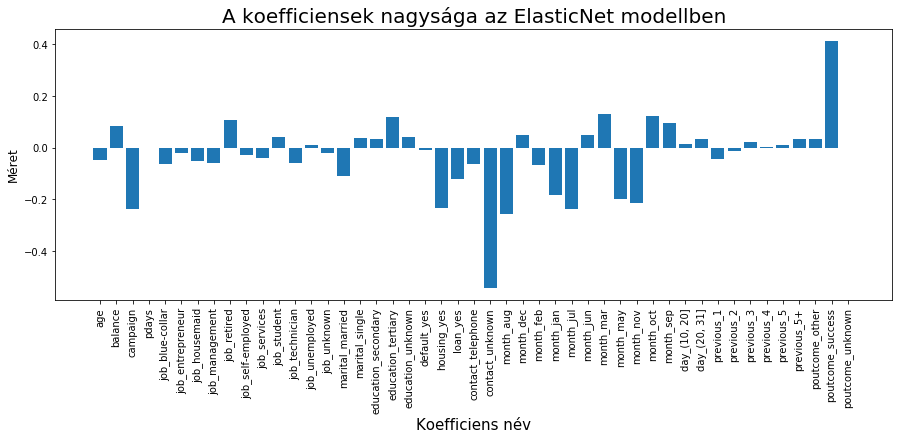

```python
objects = X_train.columns
y_pos = np.arange(len(X_train.columns))
performance = elastic_final.coef_

plt.figure(figsize=(15, 5))
plt.bar(y_pos, performance[0], align='center')
plt.xticks(y_pos, objects, rotation='vertical', size = 10)
plt.ylabel('Méret', size = 12)
plt.xlabel('Koefficiens név', size = 15)
plt.title('A koefficiensek nagysága az ElasticNet modellben', size = 20)
plt.savefig('elastic_coef.png', bbox_inches = 'tight')

plt.show()
```

A nullától jócskán nagyobb koeficienesek hatása valószínűleg nagy az Y-ra, vagyis arra hogy megvásárolják e a kötvényt az egyének. Azt is leolvashatjuk, hogy milyen az összefüggés a két változó között. Negatív, ha 0-nál kisebb vagy pozitív ha 0-nál nagyobb. Így, nagy hátsú változók a regressziós modell alapján, pl:

- putcome
- contact
- housing
- campaign

## 3.3.3 KNN modell

A KNN modellnek szükséges hasonló skalára helyezni a változókat úgymint az előző (ElasticNet-es) modell esetében. Ez a transzformáció látható a következő sorban:

```python
scaler = StandardScaler()
scaler.fit(X_train)

X_train_knn = scaler.transform(X_train)
X_test_knn = scaler.transform(X_test)
```

```python
param_grid = {'n_neighbors': [14, 15, 16],
             'n_jobs': [-1]}
#kipróbáltam kisebb K-kal is de rosszabb eredényt adott, azonban ennél följebb nem mertem
#állítani, mert nagyon sokáig tart lefuttatni

knn_cv = GridSearchCV(KNeighborsClassifier(),
                      param_grid = param_grid,
                      cv = 5,
                      scoring ='roc_auc')
```

```python
knn_cv.fit(X_train_knn, y_train)
print(knn_cv.best_params_)
```

```
{'n_jobs': -1, 'n_neighbors': 16}
```

```python
knn_final = knn_cv.best_estimator_
```

```python
knn_final_cv = model_selection.cross_val_score(knn_final,
                                              X_train_knn, y_train,
                                              cv=model_selection.KFold(n_splits=5, random_state=0),
                                              scoring='roc_auc')

print(knn_final_cv)
print('---')
results["knn"] = knn_final_cv
print("Átlagos ROC KNN modellt használva a train adatokon (CV = 5-tel): ", knn_final_cv.mean().round(3))
```

```
[0.73114698 0.72370261 0.73895784 0.73620803 0.7293454 ]
---
Átlagos ROC KNN modellt használva a train adatokon (CV = 5-tel):  0.732
```

```python
#későbbre?
knn_final_pred_train = knn_final.predict(X_train)
knn_final_test_pred = knn_final.predict(X_test)
```

## 3.3.4 Egyszerű Döntési fa (Decision Tree) modell

```python
#Hasonlóan az előző módszerhez:
param_grid = {'criterion': ['gini', 'entropy'],
              'splitter': ['best'],
              'max_depth': [3, 4, 5, 6, 7, 8, 10],
              'max_features': [7, 8, 11, 15, 20, 25],
              'min_samples_split' : [5, 10, 20, 30],
              'class_weight': [None, 'balanced']
             }


dt_cv = GridSearchCV(estimator=DecisionTreeClassifier(),
                      param_grid = param_grid,
                      cv = 5,
                      scoring ='roc_auc')
```

```python
dt_cv.fit(X_train, y_train)
print(dt_cv.best_params_)
```

```
{'class_weight': 'balanced', 'criterion': 'gini', 'max_depth': 8, 'max_features': 25, 'min_samples_split': 30, 'splitter': 'best'}
```

```python
dt_final = dt_cv.best_estimator_
```

```python
dt_final_cv = model_selection.cross_val_score(dt_final,
                                              X_train, y_train,
                                              cv=5,
                                              scoring='roc_auc')

print(dt_final_cv)
print('---')
results["decisionTree"] = dt_final_cv
print("Átlagos ROC DT modellt használva a train adatokon (CV = 5-tel): ", dt_final_cv.mean().round(3))
```

```
[0.75409721 0.72708319 0.73968021 0.74713643 0.75295056]
---
Átlagos ROC DT modellt használva a train adatokon (CV = 5-tel):  0.744
```

```python
#Későbbre?
dt_final_pred_train = dt_final.predict(X_train)
dt_final_test_pred = dt_final.predict(X_test)
```

### A döntési fa kirajzolása:

- a döntési fa tetején lévő változók a legfontosabbnak ítélt változók a modell szempontjából. A modell szerint azok a változók rendelkeznek a legtöbb információval.

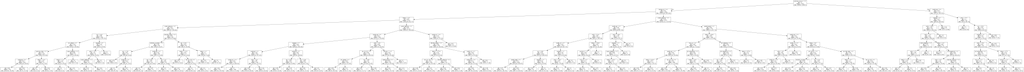

```python
dot_data = StringIO()

tree.export_graphviz(dt_final, out_file=dot_data, feature_names=X_train.columns)

graph = pydot.graph_from_dot_data(dot_data.getvalue())

Image(graph.create_png())
###doble click the picture to zoom in to it
```

## 3.3.5 Random Forest modell

```python
#hasnoló módszer, mint eddig:
param_grid = {
    'n_estimators': [300], #nem mertem nagyobbra állítani, igy is sokáig tart
    'max_features': ['auto', 'sqrt', 'log2'],
    'max_depth' : [10, 12, 15],
    'criterion' :['gini', 'entropy'],
    'class_weight': [None, 'balanced'],
    'n_jobs': [-1]
}


rf_cv = GridSearchCV(estimator=RandomForestClassifier(),
                      param_grid = param_grid,
                      cv = 5,
                      scoring ='roc_auc')
```

```python
rf_cv.fit(X_train, y_train) # training the model
print(rf_cv.best_params_)
```

```
{'class_weight': None, 'criterion': 'entropy', 'max_depth': 15, 'max_features': 'sqrt', 'n_estimators': 300, 'n_jobs': -1}
```

```python
rf_final = rf_cv.best_estimator_
```

```python
rf_final_cv = model_selection.cross_val_score(rf_final,
                                              X_train, y_train,
                                              cv=5,
                                              scoring='roc_auc')

print(rf_final_cv)
print('---')
results["rf"] = rf_final_cv
print("Átlagos ROC RandomForest modellt használva a train adatokon (CV = 5-tel): ", rf_final_cv.mean().round(3))
```

```
[0.78661147 0.77975166 0.79511165 0.7913654  0.79652661]
---
Átlagos ROC RandomForest modellt használva a train adatokon (CV = 5-tel):  0.79
```

```python
#későbbre?
rf_final_pred_train = rf_final.predict(X_train)
rf_final_test_pred = rf_final.predict(X_test)
```

### A modell által használt változók fontosságának megjelenítése:

- minél nagyobb a relatív fontosság, annál fontosabb az adott változó a kimenetelre nézve

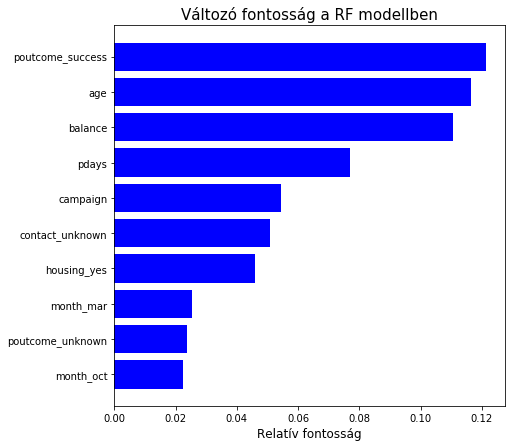

```python
features = X_train.columns

importances = rf_final.feature_importances_
indices = np.argsort(importances)[-10:]

plt.figure(figsize=(7, 7))
plt.title('Változó fontosság a RF modellben', size = 15)
plt.barh(range(len(indices)), importances[indices], color='blue', align='center')
plt.yticks(range(len(indices)), features[indices])
plt.xlabel('Relatív fontosság', size = 12)
plt.savefig('rf_importance.png', bbox_inches = 'tight')
```

- Néhány fontosnak ítélt változó a RF modellben:
  - poutcome
  - age
  - balance
  - pdays

## 3.3.6 Gradient Boosting (GBM) modell

```python
param_grid = {'learning_rate': [0.02, 0.05, 0.35, 0.5],
              'subsample': [0.8, 0.9],
              'max_depth' : [2, 3, 4],
              'n_estimators' : [30, 40, 50, 60]}


gbm_cv = GridSearchCV(estimator=GradientBoostingClassifier(),
                      param_grid = param_grid,
                      cv = 5,
                      scoring ='roc_auc')
```

```python
gbm_cv.fit(X_train, y_train)
print(gbm_cv.best_params_)
```

```
{'learning_rate': 0.35, 'max_depth': 3, 'n_estimators': 60, 'subsample': 0.9}
```

```python
gbm_final = gbm_cv.best_estimator_ #a legjobb modell kiválasztása
```

```python
gbm_final_cv = model_selection.cross_val_score(gbm_final,
                                              X_train, y_train,
                                              cv=5,
                                              scoring='roc_auc')

print(gbm_final_cv)
print('---')
results["gbm"] = gbm_final_cv
print("Átlagos ROC GBM modellt használva a train adatokon (CV = 5-tel): ", gbm_final_cv.mean().round(3))
```

```
[0.78597052 0.77223926 0.79296654 0.78361165 0.78991637]
---
Átlagos ROC GBM modellt használva a train adatokon (CV = 5-tel):  0.785
```

```python
#késöbbre?
gbm_final_pred_train = gbm_final.predict(X_train)
gbm_final_test_pred = gbm_final.predict(X_test)
```

### A modell általá használt változók fontosságának megjelenítése:

- minél nagyobb a relatív fontosság, annál fontosabb az adott változó a kimenetelre nézve

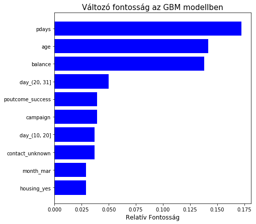

```python
features = X_train.columns

importances = gbm_final.feature_importances_
indices = np.argsort(importances)[-10:]

plt.figure(figsize=(7, 7))
plt.title('Változó fontosság az GBM modellben', size = 15)
plt.barh(range(len(indices)), importances[indices], color='blue', align='center')
plt.yticks(range(len(indices)), features[indices])
plt.xlabel('Relatív Fontosság', size = 12)
plt.savefig('gbm_importance.png', bbox_inches = 'tight')
```

- Néhány fontosnak ítélt változó a GBM modellben:
  - pdays
  - age
  - balance
  - pdays

## 3.3.7 Ada Boost (ADA) modell

```python
param_grid = {'learning_rate': [0.02, 0.05, 0.35, 0.5],
              'n_estimators': [8, 12, 18, 40, 50, 60]}


ada_cv = GridSearchCV(estimator=AdaBoostClassifier(),
                      param_grid = param_grid,
                      cv = 5,
                      scoring ='roc_auc')
```

```python
ada_cv.fit(X_train, y_train)
print(ada_cv.best_params_)
```

```
{'learning_rate': 0.5, 'n_estimators': 60}
```

```python
ada_final = ada_cv.best_estimator_ #a legjobb modell kiválasztása
```

```python
ada_final_cv = model_selection.cross_val_score(ada_final,
                                              X_train, y_train,
                                              cv=5,
                                              scoring='roc_auc')

print(ada_final_cv)
print('---')
results["ada"] = ada_final_cv
print("Átlagos ROC ADA Boost modellt használva a train adatokon (CV = 5-tel): ", ada_final_cv.mean().round(3))
```

```
[0.76846867 0.76962861 0.78412847 0.7809903  0.78197689]
---
Átlagos ROC ADA Boost modellt használva a train adatokon (CV = 5-tel):  0.777
```

```python
#késöbbre
ada_final_pred_train = ada_final.predict(X_train)
ada_final_test_pred = ada_final.predict(X_test)
```

### A modell által használt változók fontosságának megjelítnése:

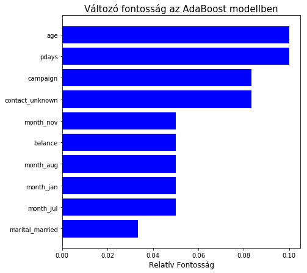

```python
features = X_train.columns

importances = ada_final.feature_importances_
indices = np.argsort(importances)[-10:]

plt.figure(figsize=(7, 7))
plt.title('Változó fontosság az AdaBoost modellben', size = 15)
plt.barh(range(len(indices)), importances[indices], color='blue', align='center')
plt.yticks(range(len(indices)), features[indices])
plt.xlabel('Relatív Fontosság', size = 12)
plt.savefig('ada_importance.png', bbox_inches = 'tight')
```

- Néhány fontosnak ítélt változó az AdaBoost modellben:
  - age
  - pdays
  - campaign
  - contact

### Neural Network modell

- Egy neurális hálón alapuló modellt, is próbáltam lefuttatni, azonban valamiért nem sikerült ki train-elni.

```python
#import keras
#from keras.optimizers import SGD
```

```python
#y_train_d = keras.utils.to_categorical(y_train, num_classes=2)
#y_test_d = keras.utils.to_categorical(y_test, num_classes=2)
```

```python
#model = keras.models.Sequential()
```

```python
#from keras.layers import Dense

#model.add(Dense(units=50, activation='relu', input_dim=71))
#model.add(Dense(units=30, activation='relu'))
#model.add(Dense(units=10, activation='relu'))
#model.add(Dense(units=2, activation='softmax'))
```

```python
#sgd = SGD(lr=0.01, decay=1e-6, momentum=0.9, nesterov=True)
#model.compile(loss=keras.losses.categorical_crossentropy,
#              optimizer=sgd,
#              metrics=['accuracy'])
```

```python
#model.fit(X_train.as_matrix(), y_train_d, epochs=10, batch_size=16)
```

```python
#loss_and_metrics = model.evaluate(X_test, y_test)
```

```python
#from sklearn.utils import class_weight

#class_weight = class_weight.compute_class_weight('balanced',
#                                                 np.unique(y_train),
#                                                 y_train)
```

```python
#loss_and_metrics
```

```python
#model.predict_proba(X_test)
```

```python
#dl_roc_auc = roc_auc_score(y_test, model.predict_proba(X_test))
```

```python
#dl_roc_auc
```

# 4. Kiértékelés (Evaluation): A legmegfelelőbb modell kiválasztása

## 4.1 A fenti modellek ROC-jének összehasonlítása

A fentebb futatott modellek ROC/AUC-re vonatkozó CV = 5 ös eredményét egy táblázatba raktam, annak érdekében, hogy össze hasonlíthatóvá váljanak. A modellek ROC-je minél jobban megközelíti az 1-et, annál jobb predikciós erővel rendelkeznek.

```python
res_df = pd.DataFrame(results)
res_df
```

|  | Benchmark Logit | ElasticNet | ada | decisionTree | gbm | knn | rf |
| --- | --- | --- | --- | --- | --- | --- | --- |
| 0 | 0.671645 | 0.765755 | 0.768469 | 0.754097 | 0.785971 | 0.731147 | 0.786611 |
| 1 | 0.681911 | 0.753924 | 0.769629 | 0.727083 | 0.772239 | 0.723703 | 0.779752 |
| 2 | 0.705018 | 0.770918 | 0.784128 | 0.739680 | 0.792967 | 0.738958 | 0.795112 |
| 3 | 0.706266 | 0.776233 | 0.780990 | 0.747136 | 0.783612 | 0.736208 | 0.791365 |
| 4 | 0.664875 | 0.769657 | 0.781977 | 0.752951 | 0.789916 | 0.729345 | 0.796527 |

Majd egy boxplot-ot csináltam belőlük:

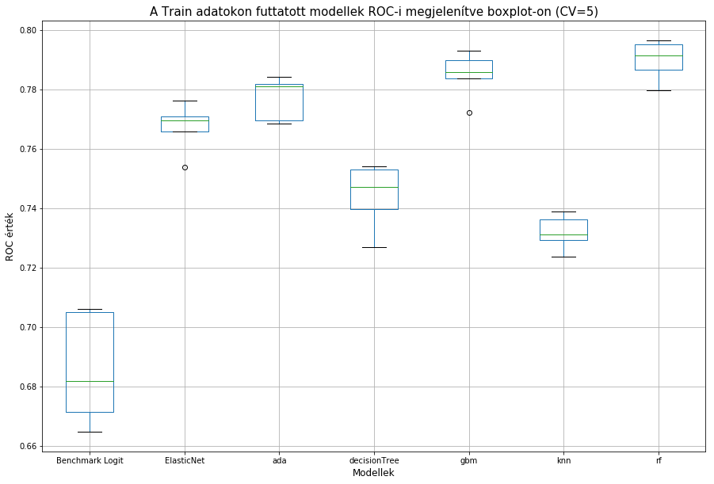

```python
_ = res_df.boxplot(figsize=(15, 10)).set_title("A Train adatokon futtatott modellek ROC-i megjelenítve boxplot-on (CV=5)", size = 15)
plt.xlabel('Modellek', size = 12)
plt.ylabel('ROC érték', size = 12)
plt.savefig('roc_boxplot.png', bbox_inches = 'tight')
```

#### Az fenti ábra alapján az alábbi következtetéseket tehetjük:

- mindegyik ML modell megveri a benchmark modellünket
- RF a legjobb modell cross validated (5 CV) ROC alapján
- az AdaBoost, ElasticNet, GBM és a RandomForest modell teljesítménye nagyon közel van egymáshoz

### Más szempontokat is figyelembe vehetünk a legmegfelelőbb modell kiválasztásához

### A fenti ábra alapján 3 modellt választottam további szempontok szerinti megvizsgálásra:

- RandomForset modell - Miért?: A legjobb az a ROC-je
- GBM modell - Miért? Közel a legjobb ROC
- ElasticNet modell - Miért?: Nem tree based modell és nem sokkal marad el a legjobb modelltől, és szükségesnek éreztem egy ilyen másik modelltípus szerepeltetését is a további elemzéshez.

### A moell validálása és az ROC-k prezentálása szemponzjából ennek 3 modelnek az ROC-jét is meg is jeleníthetjük az test adatbázison:

- A ROC görbék hasonló eredményre, de nem feltétlenül ugyanarra fognak vezetni, mint az előző boxplotról leolvasható eredmények
  - Ha közel állnak a Train adatbázison lévő ROC-khez akkor validnak mondhatjuk a modellt.
- Az AUC minél közelebb van az 1-hez annál jobb a modellünk
- a benchmark egszerű logit modellt és az ábrára raktam érdekességképpen

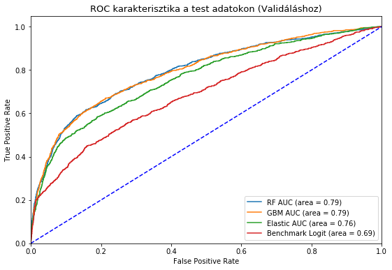

```python
rf_roc_auc = roc_auc_score(y_test, rf_final.predict_proba(X_test)[:,1])
fpr_rf, tpr_rf, thresholds_rf = roc_curve(y_test, rf_final.predict_proba(X_test)[:,1])

gbm_roc_auc = roc_auc_score(y_test, gbm_final.predict_proba(X_test)[:,1])
fpr_gbm, tpr_gbm, thresholds_gbm = roc_curve(y_test, gbm_final.predict_proba(X_test)[:,1])

elastic_roc_auc = roc_auc_score(y_test, elastic_final.predict_proba(X_test_elastic)[:,1])
fpr_el, tpr_el, thresholds_el = roc_curve(y_test, elastic_final.predict_proba(X_test_elastic)[:,1])

plt.figure(figsize=(9, 6))

plt.plot(fpr_rf, tpr_rf, label='RF AUC (area = %0.2f)' % rf_roc_auc)
plt.plot(fpr_gbm, tpr_gbm, label='GBM AUC (area = %0.2f)' % gbm_roc_auc)
plt.plot(fpr_el, tpr_el, label='Elastic AUC (area = %0.2f)' % elastic_roc_auc)

plt.plot(fpr_b, tpr_b, label='Benchmark Logit (area = %0.2f)' % benchmark_logit_roc_auc)

plt.plot([0, 1], [0, 1],'b--')
plt.xlim([0.0, 1.0])
plt.ylim([0.0, 1.05])
plt.xlabel('False Positive Rate')
plt.ylabel('True Positive Rate')
plt.title('ROC karakterisztika a test adatokon (Validáláshoz)', size = 13)
plt.legend(loc="lower right")
plt.savefig('roc_curves.png', bbox_inches = 'tight')

plt.show()
```

- Mind a 3 modellt validnak tekintem, mert nem állnak a ROC görbéji távol a test set-en kiszámoltakhoz.
- Ez alapján a 3 kiválasztót modell között a predikciós erő szerint a random forest és a GBM jobbnak tekinthető az ElasticNet-es modellnél

Azonban megnézhetjük a modellek kalibrációs görbéit, amiből láthatjuk, hogy vajon az egyes modellek egyaránt konzisztensen becsülnek-e a kis valószínűségű eseményekre és a nagy valószínűségi eseményekre vonatkozóan is.

### 4.2. A 3 modell kalibrációs görbéje:

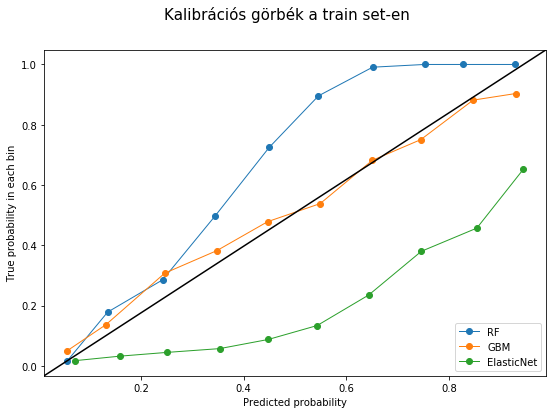

```python
rf_prediction = rf_final.predict_proba(X_train)
gbm_prediction = gbm_final.predict_proba(X_train)
elastic_prediction = elastic_final.predict_proba(X_train_elastic)

rf_y, rf_x = calibration_curve(y_train, rf_prediction[:,1], n_bins=10)
gbm_y, gmb_x = calibration_curve(y_train, gbm_prediction[:,1], n_bins=10)
elastic_y, elastic_x = calibration_curve(y_train, elastic_prediction[:,1], n_bins=10)


fig, ax = plt.subplots(figsize=(9, 6))

plt.plot(rf_x,rf_y, marker='o', linewidth=1, label='RF')
plt.plot(gmb_x, gbm_y, marker='o', linewidth=1, label='GBM')
plt.plot(elastic_x, elastic_y, marker='o', linewidth=1, label='ElasticNet')

line = mlines.Line2D([0, 1], [0, 1], color='black')
transform = ax.transAxes
line.set_transform(transform)
ax.add_line(line)
fig.suptitle('Kalibrációs görbék a train set-en', size = 15)
ax.set_xlabel('Predicted probability')
ax.set_ylabel('True probability in each bin')
plt.legend(loc="lower right")
plt.savefig('calibration_plot.png', bbox_inches = 'tight')

plt.show()
```

#### A kalibrációs görbe annál jobb, minél közelebb húzódik az 1 meredekségű fekete egyeneshez. Ez alapján:

- A GBM modellnek a legjobb a kalibrációs görbéje.
- A RF modell sok helyen félrekalibrált
- Az ElasitcNet kalibrációs görbéje félre kalibrált, de az ellenkező irányba, mint a RF modellnek

# 4.4. Végső modell, amit a legjobbnak ítéltem: GBM

- Miért?
  - ROC-je magas, hasonló, mint az RF-nek
  - jobb a kalibrációs görbéje

## 4.5. A GBM modell eredményei a tran és a test adatbázison

- Miután kiválasztottam az általam ítált legjobb modellt. Confusion matrixban megjelenítem a valós eredményeit
- A train és a teszt adatbázison is
  - szemléletes
  - validálást megerősíti

### Confusion mátrix az eremények ismertetéséhez:

- train adatbázison:

```python
pd.DataFrame(
    confusion_matrix(y_train, gbm_final_pred_train),
    columns=['Predicted y no', 'Predicted y yes'],
    index=['True y no', 'True y yes']
)
```

|  | Predicted y no | Predicted y yes |
| --- | --- | --- |
| True y no | 31485 | 478 |
| True y yes | 3089 | 1109 |

- teszt adatbázison:

```python
pd.DataFrame(
    confusion_matrix(y_test, gbm_final_test_pred),
    columns=['Predicted y no', 'Predicted y yes'],
    index=['True y no', 'True y yes']
)
```

|  | Predicted y no | Predicted y yes |
| --- | --- | --- |
| True y no | 7812 | 139 |
| True y yes | 851 | 239 |

A modell mind a test és a train adatbázison arányaiban hasonló eredményt ad. Ez jó modell kalibrálásra utal. És ez alapján is validnak fogadom el a modellt  
Azonban sok valós pozitív megfigyelést nem találunk meg az alap beállításokkal. Ezt módosíthatjuk úgy, hogy a klasszifikáció határát megváltoztatjuk. Alapból a modell, ahol 0.5 feletti esélyt prediktál az egyénnek azt 'yes' nek klasszifikálja, de ezt a 0.5-ös értéket módosíthatjuk is egy kisebb vagy egy nagyobb értékre az üzleti igények szerint.  
Egy alacsonyabb értéknél több true pozitív értékünk lesz. Azonban ennek ára van. A false pozitív megfigyelésünk száma is megnövekszik.  
Lássunk ezt gyakorlatban:

```python
def conf_mat_thres(pred_true, model, data, threshold = 0.5):
    model_percent = model.predict_proba(data)
    new_pred = np.where(model_percent[:,1] > threshold, 1, 0)
    return(
        pd.DataFrame(
            confusion_matrix(pred_true, new_pred),
            columns=['Predicted y no', 'Predicted y yes'],
            index=['True y no', 'True y yes'])
    )
```

```python
conf_mat_thres(pred_true= y_train, model = gbm_final, data = X_train, threshold=0.3)
```

|  | Predicted y no | Predicted y yes |
| --- | --- | --- |
| True y no | 30587 | 1376 |
| True y yes | 2428 | 1770 |

- test adatokon (threshold = 0.3):

```python
conf_mat_thres(pred_true= y_test, model = gbm_final, data = X_test, threshold=0.3)
```

|  | Predicted y no | Predicted y yes |
| --- | --- | --- |
| True y no | 7568 | 383 |
| True y yes | 670 | 420 |

Ha még lejebb visszük a thresholdot akkor a következőt kapjuk:

- train adatokon:

```python
conf_mat_thres(pred_true= y_train, model = gbm_final, data = X_train, threshold=0.15)
```

|  | Predicted y no | Predicted y yes |
| --- | --- | --- |
| True y no | 28671 | 3292 |
| True y yes | 1782 | 2416 |

- test adatokon

```python
conf_mat_thres(pred_true= y_test, model = gbm_final, data = X_test, threshold=0.15)
```

|  | Predicted y no | Predicted y yes |
| --- | --- | --- |
| True y no | 7099 | 852 |
| True y yes | 505 | 585 |

Láthatjuk, hogy ebben az esetben már egy jelentősebb részét megtaláltuk, a true pozitív eseteknek, azonben ennek az az ára, hogy sok esetben azt, prediktáljuk, hogy valaki meg fogja venni a terméket, azonban ez nem így történik.

## 4.6. A GBM modell legfontosabbnak ítélt változói és a vásárlási hajlandóság (y) összefüggései

A log-olt age változó visszaalkaítása:

```python
data['age'] = np.exp(data['age'])
```

Az y-n 1 és 0 vá alakítása:

```python
data['y_num'] = data.y.map(dict(yes=1, no=0))
```

### age

- ez a váltózó elsőre, nem tünt annyira jelentősnek, de sokszor szereplet a modellek variable importance plot-jában ezért jobban megvizsgáltam

```python
data['age_group'] = pd.cut(data.age, range(15, 90, 10), right=False)
```

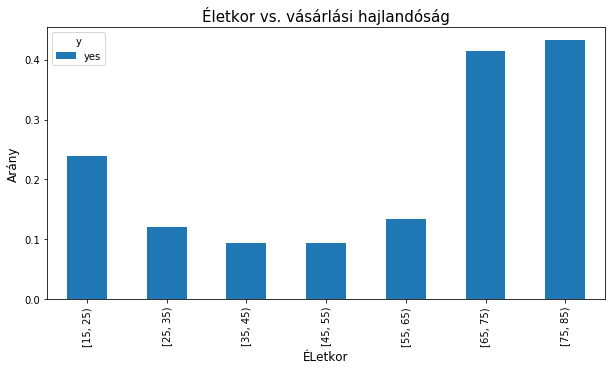

```python
table=pd.crosstab(data.age_group,data.y)
plot = table.div(table.sum(1).astype(float), axis=0)[['yes']].plot.bar(figsize = (10, 5))
plot.set_title('Életkor vs. vásárlási hajlandóság', size = 15)
plot.set_xlabel('ÉLetkor', size = 12)
plot.set_ylabel('Arány', size = 12)
plt.savefig('age.png', bbox_inches = 'tight')
```

- A vásárlási hajlandóság nagy a 65+ -os korosztályban, de a fiatalok 15-25 évesek is nagy arányban vásárolnak
- 15-től 45 éves korig csökken a vásárlási hajlandóság
- 45-55 éves korig kb. konstans
- 65 + kortól egy jóval nagyobb ugrás található a vásárlási hajlandóságban, majdnem 50% ezen korcsoportnak vásárol a termékből. (Azonban a 65+-os megfigyelések száma alacsony)

### pdays

- ez a változó azt mutatja, hogy hány nappal ezelött volt egy előző kampányban kontaktálva az adott személlyel
- -1 is lehet ebben a változóban, ez azt indikálja, hogy még soha nem volt kontakt az ügyféllel

```python
data['pdays_group'] = pd.cut(data.pdays, [-1, 0, 25, 50, 100, 200, max(data['pdays'])], right=False)
```

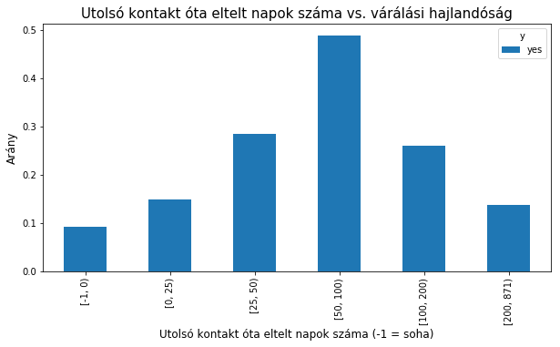

```python
table=pd.crosstab(data.pdays_group,data.y)
plot = table.div(table.sum(1).astype(float), axis=0)[['yes']].plot.bar(figsize = (10,5))
plot.set_title('Utolsó kontakt óta eltelt napok száma vs. várálási hajlandóság', size = 15)
plot.set_ylabel('Arány', size = 12)
plot.set_xlabel('Utolsó kontakt óta eltelt napok száma (-1 = soha)', size = 12)
plt.savefig('pdays.png', bbox_inches = 'tight')
```

- Akiket még nem hívtak (-1) ott a legalacsonyabb a vásárlási arány
- Mindenhol magasabb a vásárlási arány, akit már legalább egyszer hívtak. (Lehet hogy azért mert már ismer és jobban bízik? De lehet azért mert már eladtak nekünk előzőleg valamilyen terméket és a bank ügyfelei?)
- 100 nap eltelte közelében a legnagyobb a vásárlási arány
- 0-tól 100 napig a vásárlási arány folyamatosan nő
- 100 nap elteltével a vásárlási arány azonban csökkeni kezd!

### balance

- az egyenlegre vonatkozó változó
- vajon az alacsonyabb vagy a magasabb vagyonúak veszik nagyobb arányban a terméket?

```python
data['balance_group'] = pd.cut(data.balance, [min(data['balance']),-1000, -500, 0, 1000, 2000, 5000, 10000, max(data['balance'])], right=False)
```

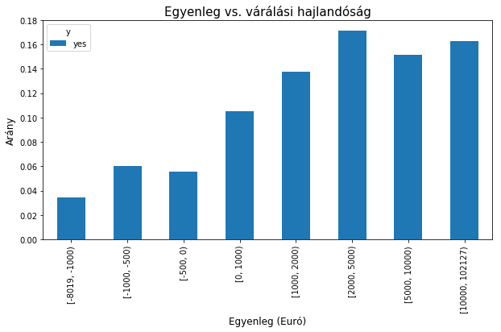

```python
table=pd.crosstab(data.balance_group,data.y)
plot = table.div(table.sum(1).astype(float), axis=0)[['yes']].plot.bar(figsize = (10,5))
plot.set_title('Egyenleg vs. várálási hajlandóság', size = 15)
plot.set_ylabel('Arány', size = 12)
plot.set_xlabel('Egyenleg (Euró)', size = 12)
plt.savefig('balance.png', bbox_inches = 'tight')
```

- Nagyobb egyenleg nagyobb vásárlási hajlandóság, egészen 5000 euróig, ahol konstanssá válik az arány
- azok akiknek negatív az egyenlegük sokkal kisebb arányban vesznek a termékből
- akiknek nagyon alacsony azok (szinte) semmit
- egy bizonyos összeg fölött, már nem növekszik a vásárlási hajlandóság.

### putcome

- sokszor mutatta a modell, hogy azok, akiknél az előző marketig kampány sikeres volt az nagy hatással, van a mostani marketing kampányra is

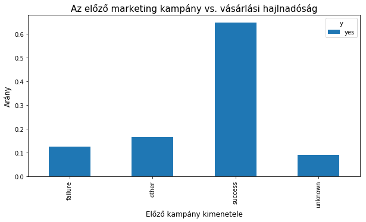

```python
table=pd.crosstab(data.poutcome,data.y)
plot = table.div(table.sum(1).astype(float), axis=0)[['yes']].plot.bar(figsize = (10,5))
plot.set_title('Az előző marketing kampány vs. vásárlási hajlnadóság', size = 15)
plot.set_ylabel('Arány', size = 12)
plot.set_xlabel('Előző kampány kimenetele', size = 12)
plt.savefig('putcome.png', bbox_inches = 'tight')
```

- Akiknél az előző marketing kampány sikeres volt sokkal nagyobb arányban vásárolnak a termékből
- A többi csoportban a vásárlási arány kb. megegyezik

# 5. Alkalmazás (Deployment):

#### Az alkalmazásra vonatkozó tanácsaim attól függők, hogy milyen vállalat döntéshozóinak készíteném elő az elemzésem. Gondolok itt a következőre:

- Egy csak sales tevékenységet végző vállalat számára a modellem által nagy valószínűséggel társító egyéneket javasolnám felhívásra/ megkeresésre. Így a vállalat maximalizálni tudná a jutalékját. A szűkös erőforrásaikat a modellem segítségével jobban optimalizálhatnák. *életkor szerint a 15-35-as és a 65+-os korosztályt lenne érdemes felkeresni
  - olyanokat lenne érdemes felhívni, akiket már felhívtak és sikeresen eladtak nekik más terméket és kb. 100 napja volt az utolsó kontaktálás
  - akiknek pozitív a számla egyenlegük
- Egy bank esetében azonban szükséges lenne magát a marketing kampány hatását lemérni, mert ez most nem olvasható ki az adatbázisból.
  - Miért? Mivel nem találhatóak benne olyan egyénekre vonatkozó megfigyelések, akik nem vettek részt a marketing kampányban, és így nem tudjuk a marketing kampány hatását vizsgálni. Nincs mihez viszonyítanunk, így nem tudjuk a hozzáadott értékét sem. Gondoljunk bele abba, hogy lehet, hogy az adott egyén a marketing kampány nélkül is megvásárolta volta a bankfiókban a terméket, így a telefonos megkeresésnek semmi hatása nem volt a döntésére nézve.
  - Tkp. egy A/B tesztelésre lenne szükség, amit a mostani adatbázis nem, vagy csak kevésbé tesz lehetővé

#### További szükséges változók, amiket szerepeltetnék az adatbázisban:

- Jó irány lenne mérni a sales tevékenység hatását, így megtudhatnánk:
  - Mely egyéneket szükséges megcéloznunk --> marketing kampány hatása * populációs részarány
  - Szükséges ehhez: olyan személyek is az adatbázisba, akik nem vettek részt a marketing kampányban
  - Új változó: Treated/ Not Treated
- Milyen szoláltatása van a banknál, ha van az adott személynek:
  - Cross sell és up sell
- További változók, amiket fontos információt tartalmazhatnak:
  - Mikor történt a hívás pontosan és mikor történt a vásárlás pontosan
  - ÉV: ki lehetne számolni a hétvége hétkönapot hétvége/ hétköznap
  - Hívás pontos ideje: reggel/este/stb.
  - Nem: fogadó neme és hívó neme (vajon kiknek milyen neművel érdemes eladni, van-e ennek hatása?)

# ---------------------------------------------------------------------------

# FUN part:

# RF using all the features (add duration to the predictors)

- I am traingin a Random Forest model with all the predictors to see what is the best possible outcome if we are using the 'duration' variable as well

```python
# RF with using all features:
# Fiter columns if you want:
X = ['age','job','marital', 'education', 'default', 'balance', 'housing', 'loan',
     'contact', 'campaign', 'pdays', 'previous', 'poutcome', 'duration', 'month', 'day', 'y']

categorical_vars = ['job', 'marital', 'education', 'default',
                   'housing', 'loan', 'contact', 'month', 'day',
                   'previous', 'poutcome', 'y']

ml_data = data[X]

ml_data = pd.get_dummies(ml_data, columns = categorical_vars, drop_first=True)
```

```python
# train and test split
X_train, X_test, y_train, y_test = train_test_split(ml_data.drop('y_yes', axis=1),
                                                    ml_data['y_yes'],
                                                    test_size=0.2)
```

```python
#set up the paramters of the rf model with CV:
param_grid = {
    'n_estimators': [300], # may set higher, but computationally intensive
    'max_features': [2, 'auto', 'sqrt', 'log2'],
    'max_depth' : [5, 8, 10, 12],
    'criterion' :['gini', 'entropy'],
    'class_weight': [None, 'balanced'],
    'n_jobs': [-1]
}


rf_cv_duration = GridSearchCV(RandomForestClassifier(),
                      param_grid = param_grid,
                      cv = 5,
                      scoring ='roc_auc')
```

```python
#train the models and selecting the best parameters with the help of grid search and CV
rf_cv_duration.fit(X_train, y_train)
print(rf_cv_duration.best_params_)
```

```
{'class_weight': None, 'criterion': 'entropy', 'max_depth': 12, 'max_features': 'sqrt', 'n_estimators': 300, 'n_jobs': -1}
```

```python
#get the best model
rf_final_duration = rf_cv_duration.best_estimator_
```

```python
#evaluate the best
rf_final_cv_duration = model_selection.cross_val_score(rf_final_duration,
                                              X_train, y_train,
                                              cv=model_selection.KFold(n_splits=5, random_state=0),
                                              scoring='roc_auc')

print(rf_final_cv_duration)
print('---')
print("Átlagos ROC RF modellt használva a train adatokon az összes változót, beleértve a 'duration'-t is használva (CV = 5-tel):")
print(rf_final_cv_duration.mean().round(3))
```

```
[0.91851233 0.92918809 0.93129472 0.92438203 0.92070787]
---
Átlagos ROC RF modellt használva a train adatokon az összes változót, beleértve a 'duration'-t is használva (CV = 5-tel):
0.925
```

We can see that if we add the duration variable to our estimators the AUC will be so much higher. The question holds here that do we realy alowed to use this variable or not?

- I used only in this model the duration variable
- Previous models were not contained it

```python
rf_final_duration_pred_train = rf_final_duration.predict(X_train)
rf_final_duration_test_pred = rf_final_duration.predict(X_test)
```

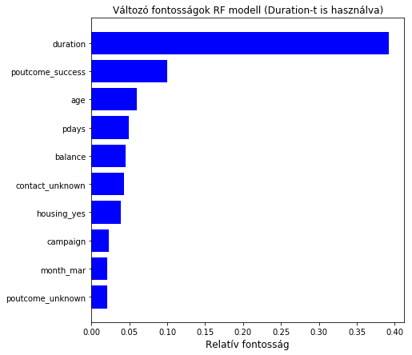

```python
features = X_train.columns

importances = rf_final_duration.feature_importances_
indices = np.argsort(importances)[-10:]

plt.figure(figsize=(7, 7))
plt.title('Változó fontosságok RF modell (Duration-t is használva)')
plt.barh(range(len(indices)), importances[indices], color='blue', align='center')
plt.yticks(range(len(indices)), features[indices])
plt.xlabel('Relatív fontosság', size = 12)
plt.savefig('rf_importance_duration.png', bbox_inches = 'tight')
```

A variable importance plot is showing that the most important variable is the duration by far.

```python
conf_mat_thres(pred_true= y_train, model = rf_final_duration, data = X_train, threshold=0.25)
```

|  | Predicted y no | Predicted y yes |
| --- | --- | --- |
| True y no | 29614 | 2320 |
| True y yes | 789 | 3438 |

```python
conf_mat_thres(pred_true= y_test, model = rf_final_duration, data = X_test, threshold=0.25)
```

|  | Predicted y no | Predicted y yes |
| --- | --- | --- |
| True y no | 7305 | 675 |
| True y yes | 311 | 750 |

## Duration vs. Y

```python
data['duration'] = np.exp(data['duration']) - 1
```

```python
data['duration_group'] = pd.cut(data.balance, [min(data['duration']), 60, 120, 240, 480, 960, max(data['duration'])], right=False)
```

[figure not shown]

```python
table=pd.crosstab(data.duration_group,data.y)
plot = table.div(table.sum(1).astype(float), axis=0)[['yes']].plot.barh(figsize = (5,8))
plot.set_title('Duration vs. várálási hajlandóság')
plot.set_xlabel('Arány')
plot.set_ylabel('Beszélgetési idő (sec)')
plt.savefig('duration_5_8.png', bbox_inches = 'tight')
```

# Final part

- We traind several models and found GBM and Random Forest among the best ones
- During the analysis it turned out that the most important predictors in the dataset:
  - duration (but we droped it)
  - putcome
  - pday
  - age
  - blance